# prices

```python
import pandas as pd
import numpy as np

train = pd.read_csv('train.csv')
test = pd.read_csv('test.csv')
```

```python
print "Train data shape:" , train.shape
print "Test data shape:" , test.shape
```

```
Train data shape: (1460, 81)
Test data shape: (1459, 80)
```

```python
train.head()
```

|  | Id | MSSubClass | MSZoning | LotFrontage | LotArea | Street | Alley | LotShape | LandContour | Utilities | ... | PoolArea | PoolQC | Fence | MiscFeature | MiscVal | MoSold | YrSold | SaleType | SaleCondition | SalePrice |
| --- | --- | --- | --- | --- | --- | --- | --- | --- | --- | --- | --- | --- | --- | --- | --- | --- | --- | --- | --- | --- | --- |
| 0 | 1 | 60 | RL | 65.0 | 8450 | Pave | NaN | Reg | Lvl | AllPub | ... | 0 | NaN | NaN | NaN | 0 | 2 | 2008 | WD | Normal | 208500 |
| 1 | 2 | 20 | RL | 80.0 | 9600 | Pave | NaN | Reg | Lvl | AllPub | ... | 0 | NaN | NaN | NaN | 0 | 5 | 2007 | WD | Normal | 181500 |
| 2 | 3 | 60 | RL | 68.0 | 11250 | Pave | NaN | IR1 | Lvl | AllPub | ... | 0 | NaN | NaN | NaN | 0 | 9 | 2008 | WD | Normal | 223500 |
| 3 | 4 | 70 | RL | 60.0 | 9550 | Pave | NaN | IR1 | Lvl | AllPub | ... | 0 | NaN | NaN | NaN | 0 | 2 | 2006 | WD | Abnorml | 140000 |
| 4 | 5 | 60 | RL | 84.0 | 14260 | Pave | NaN | IR1 | Lvl | AllPub | ... | 0 | NaN | NaN | NaN | 0 | 12 | 2008 | WD | Normal | 250000 |

5 rows × 81 columns

```python
import matplotlib.pyplot as plt
plt.style.use(style='ggplot')
plt.rcParams['figure.figsize'] = (10, 6)
%config InlineBackend.figure_format = 'retina'
```

Now we use np.log() to transform train.SalePric and calculate the skewness a second time, as well as re-plot the data. A value closer to 0 means that we have improved the skewness of the data. We can see visually that the data will more resembles a normal distribution.

```python
train.SalePrice.describe()
```

```
count      1460.000000
mean     180921.195890
std       79442.502883
min       34900.000000
25%      129975.000000
50%      163000.000000
75%      214000.000000
max      755000.000000
Name: SalePrice, dtype: float64
```

```
('Skew is:', 1.8828757597682129)
```

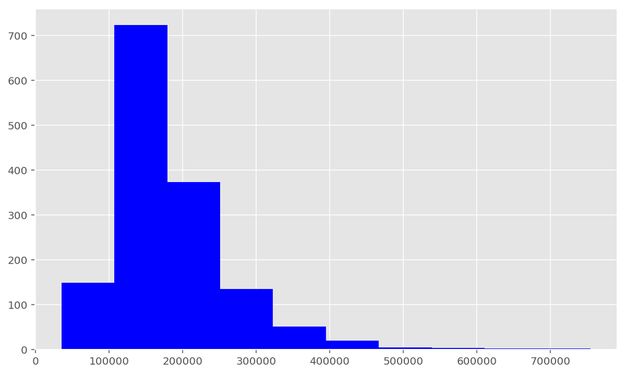

```python
print ("Skew is:", train.SalePrice.skew())
plt.hist(train.SalePrice, color='blue')
plt.show()
```

```
('Skew is:', 0.12133506220520406)
```

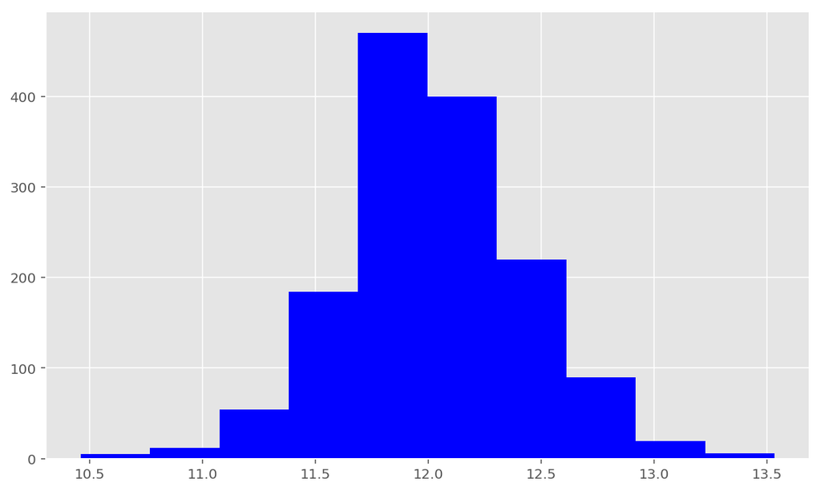

```python
target = np.log(train.SalePrice)
print ("Skew is:", target.skew())
plt.hist(target, color='blue')
plt.show()
```

```python
numeric_features = train.select_dtypes(include=[np.number])
numeric_features.dtypes
```

```
Id                 int64
MSSubClass         int64
LotFrontage      float64
LotArea            int64
OverallQual        int64
OverallCond        int64
YearBuilt          int64
YearRemodAdd       int64
MasVnrArea       float64
BsmtFinSF1         int64
BsmtFinSF2         int64
BsmtUnfSF          int64
TotalBsmtSF        int64
1stFlrSF           int64
2ndFlrSF           int64
LowQualFinSF       int64
GrLivArea          int64
BsmtFullBath       int64
BsmtHalfBath       int64
FullBath           int64
HalfBath           int64
BedroomAbvGr       int64
KitchenAbvGr       int64
TotRmsAbvGrd       int64
Fireplaces         int64
GarageYrBlt      float64
GarageCars         int64
GarageArea         int64
WoodDeckSF         int64
OpenPorchSF        int64
EnclosedPorch      int64
3SsnPorch          int64
ScreenPorch        int64
PoolArea           int64
MiscVal            int64
MoSold             int64
YrSold             int64
SalePrice          int64
dtype: object
```

DataFrame.corr()方法可以给出两个列之间的相关性，我们利用该方法用于检测特征和目标变量之间的相关性。

```python
corr = numeric_features.corr()
print corr['SalePrice'].sort_values(ascending=False)
```

```
SalePrice        1.000000
OverallQual      0.790982
GrLivArea        0.708624
GarageCars       0.640409
GarageArea       0.623431
TotalBsmtSF      0.613581
1stFlrSF         0.605852
FullBath         0.560664
TotRmsAbvGrd     0.533723
YearBuilt        0.522897
YearRemodAdd     0.507101
GarageYrBlt      0.486362
MasVnrArea       0.477493
Fireplaces       0.466929
BsmtFinSF1       0.386420
LotFrontage      0.351799
WoodDeckSF       0.324413
2ndFlrSF         0.319334
OpenPorchSF      0.315856
HalfBath         0.284108
LotArea          0.263843
BsmtFullBath     0.227122
BsmtUnfSF        0.214479
BedroomAbvGr     0.168213
ScreenPorch      0.111447
PoolArea         0.092404
MoSold           0.046432
3SsnPorch        0.044584
BsmtFinSF2      -0.011378
BsmtHalfBath    -0.016844
MiscVal         -0.021190
Id              -0.021917
LowQualFinSF    -0.025606
YrSold          -0.028923
OverallCond     -0.077856
MSSubClass      -0.084284
EnclosedPorch   -0.128578
KitchenAbvGr    -0.135907
Name: SalePrice, dtype: float64
```

- 前5个特征与SalePrice正相关，后5个特征与SalePrice负相关。为了进一步了解Over11Qual，可以利用unique()方法获取唯一值（unique values）。

```python
train.OverallQual.unique()
```

```
array([ 7,  6,  8,  5,  9,  4, 10,  3,  1,  2])
```

Over11Qual数据是1~10的整数。建立一个数据透视表（pivot table，https://en.wikipedia.org/wiki/Pivot_table），以便深入分析Over11Qual和SalePrice之间的关系。Pandas文档（Pandas docs http://pandas.pydata.org/pandas-docs/stable/reshaping.html）演示了如何完成分析工作。先设定“index='OverallQual'”、“values='SalePrice'”，进而查看median的值。

```python
quality_pivot = train.pivot_table(index='OverallQual', values="SalePrice", aggfunc=np.median)
```

```python
quality_pivot
```

| OverallQual | SalePrice |
| --- | --- |
| 1 | 50150 |
| 2 | 60000 |
| 3 | 86250 |
| 4 | 108000 |
| 5 | 133000 |
| 6 | 160000 |
| 7 | 200141 |
| 8 | 269750 |
| 9 | 345000 |
| 10 | 432390 |

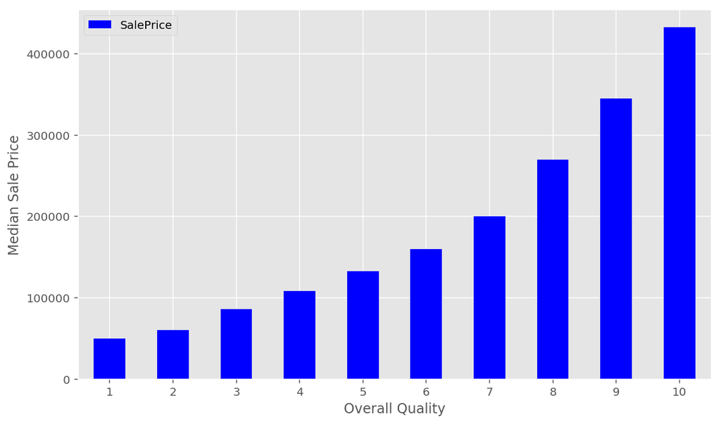

```python
quality_pivot.plot(kind='bar', color='blue')
plt.xlabel("Overall Quality")
plt.ylabel("Median Sale Price")
plt.xticks(rotation=0)
plt.show()
```

透过上图可以看出销售价格的中位数随着数量的增加而增加。接下来应用plt.scatter()生成散点图，对居住面积GrLivArea和SalePrice的关系进行可视化分析。

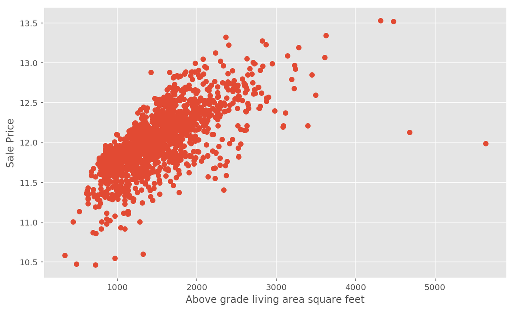

```python
plt.scatter(x=train['GrLivArea'], y=target)
plt.ylabel("Sale Price")
plt.xlabel("Above grade living area square feet")
plt.show()
```

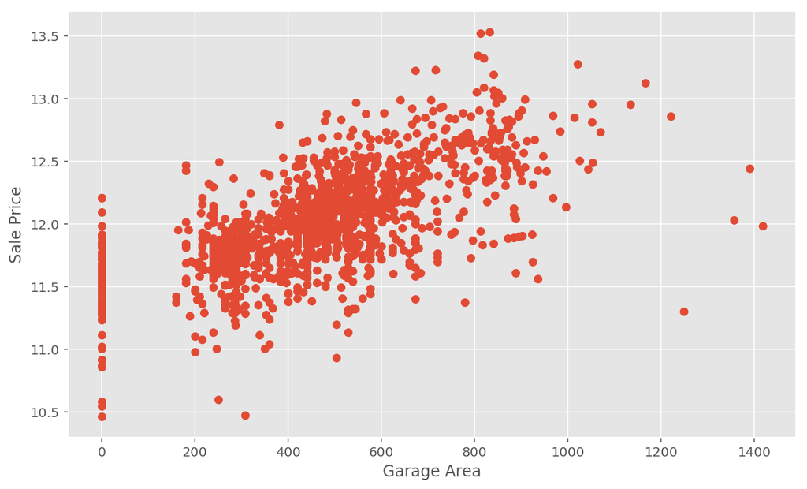

```python
plt.scatter(x=train['GarageArea'], y=target)
plt.ylabel("Sale Price")
plt.xlabel("Garage Area")
plt.show()
```

通过上图，可以看出许多房屋的Garage Area是0，表明这些房屋没有配备车库，稍后我们会利用其他特征反映这个猜测。图中显示存在一些奇异值（outliners, https://en.wikipedia.org/wiki/Outlier），这些奇异值会使预测回归线远离真实的回归线，进而影响回归模型。为保证回归模型的准确性，我们需要剔除这些奇异值。剔除野值既是技巧也是科学，有很多技术可以处理野值。

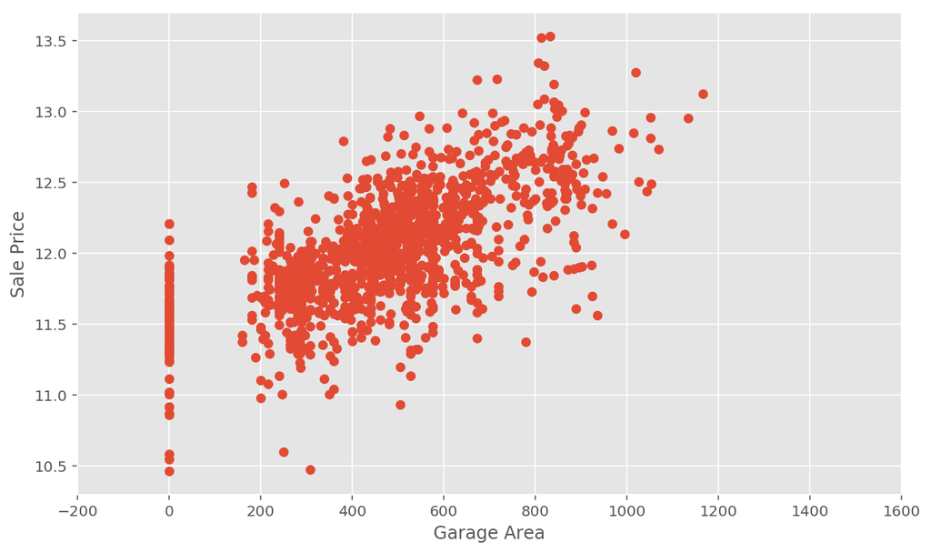

```python
train = train[train['GarageArea'] < 1200]

plt.scatter(x=train['GarageArea'], y=np.log(train.SalePrice))
plt.xlim(-200, 1600)
plt.ylabel("Sale Price")
plt.xlabel("Garage Area")
plt.show()
```

```python
nulls = pd.DataFrame(train.isnull().sum().sort_values(ascending=False)[:25])
nulls.columns = ['Null Counts']
nulls.index.name = 'Feature'
nulls
```

| Feature | Null Counts |
| --- | --- |
| PoolQC | 1449 |
| MiscFeature | 1402 |
| Alley | 1364 |
| Fence | 1174 |
| FireplaceQu | 689 |
| LotFrontage | 258 |
| GarageCond | 81 |
| GarageType | 81 |
| GarageYrBlt | 81 |
| GarageFinish | 81 |
| GarageQual | 81 |
| BsmtExposure | 38 |
| BsmtFinType2 | 38 |
| BsmtFinType1 | 37 |
| BsmtCond | 37 |
| BsmtQual | 37 |
| MasVnrArea | 8 |
| MasVnrType | 8 |
| Electrical | 1 |
| Utilities | 0 |
| YearRemodAdd | 0 |
| MSSubClass | 0 |
| Foundation | 0 |
| ExterCond | 0 |
| ExterQual | 0 |

该文档可以帮助我们了解缺少的值。 PoolQC表示泳池质量（Pool Quality）。当PoolArea为0时，泳池质量是NaN，或者是没有泳池。

我们可以在与车库相关的列之间找到相似的关系。

```python
print "unique values are:", train.MiscFeature.unique()
```

```
 unique values are: [nan 'Shed' 'Gar2' 'Othr' 'TenC']
```

```python
categoricals = train.select_dtypes(exclude=[np.number])
categoricals.describe()
```

|  | MSZoning | Street | Alley | LotShape | LandContour | Utilities | LotConfig | LandSlope | Neighborhood | Condition1 | ... | GarageType | GarageFinish | GarageQual | GarageCond | PavedDrive | PoolQC | Fence | MiscFeature | SaleType | SaleCondition |
| --- | --- | --- | --- | --- | --- | --- | --- | --- | --- | --- | --- | --- | --- | --- | --- | --- | --- | --- | --- | --- | --- |
| count | 1455 | 1455 | 91 | 1455 | 1455 | 1455 | 1455 | 1455 | 1455 | 1455 | ... | 1374 | 1374 | 1374 | 1374 | 1455 | 6 | 281 | 53 | 1455 | 1455 |
| unique | 5 | 2 | 2 | 4 | 4 | 2 | 5 | 3 | 25 | 9 | ... | 6 | 3 | 5 | 5 | 3 | 3 | 4 | 4 | 9 | 6 |
| top | RL | Pave | Grvl | Reg | Lvl | AllPub | Inside | Gtl | NAmes | Norm | ... | Attchd | Unf | TA | TA | Y | Ex | MnPrv | Shed | WD | Normal |
| freq | 1147 | 1450 | 50 | 921 | 1309 | 1454 | 1048 | 1378 | 225 | 1257 | ... | 867 | 605 | 1306 | 1321 | 1335 | 2 | 157 | 48 | 1266 | 1196 |

4 rows × 43 columns

对于这些特征，我们希望用one-hot encoding（https://www.quora.com/What-is-one-hot-encoding-and-when-is-it-used-in-data-science）法建模。one-hot encoding可以将分类数据（categorical data）转化为数值。通过这种转化，模型可以理解特定观测属于哪一类别。

转换和工程化特征（transforming and engineering features）

在转换特征时，需要记住在适应模型前对训练数据进行的变换，并对测试数据进行同样的变换。

我们的模型预期train数据集的特征形状与test数据集相匹配，即在train数据集工程化的特征也可以应用在test数据集。下面将以Street数据集为例来演示这个过程，Street表示到达房屋的路是Gravel还是Paved。

```python
print "Original:", train.Street.value_counts()
```

```
Original: Pave    1450
Grvl       5
Name: Street, dtype: int64
```

Street列的唯一值（unique values）是Pave和Grvl，用来描述到房屋道路的类型。在训练集中，5所房屋有碎石路。我们的模型需要数字数据，因此应用one-hot encoding法将Street数据转化为布尔列。创建一个新的列enc_street，pd.get_dummies()方法可以完成将数据转换成布尔量的工作。如前文所述，需要对train数据和test数据进行同样的处理。

```python
train['enc_street'] = pd.get_dummies(train.Street, drop_first=True)
test['enc_street'] = pd.get_dummies(test.Street, drop_first=True)
print "Encoded:",train.enc_street.value_counts()
```

```
Encoded: 1    1450
0       5
Name: enc_street, dtype: int64
```

处理之后的值可以用来训练、测试模型，这是工程化的第一个特征。特征工程化是对数据特征进行处理，使其成为适合于机器学习和建立模型。将Street特征转变为布尔列，这就是工程化了一个特征。

让我们试着对其他特征工程化。下面将对SaleCondition进行处理，就像刚刚对OverallQual所做的一样。

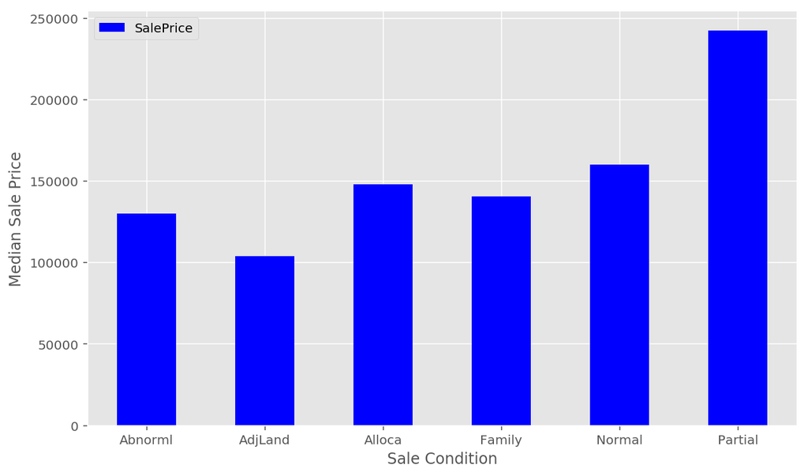

```python
condition_pivot = train.pivot_table(index='SaleCondition', values='SalePrice', aggfunc=np.median)
condition_pivot.plot(kind='bar',color='blue')
plt.xlabel('Sale Condition')
plt.ylabel('Median Sale Price')
plt.xticks(rotation=0)
plt.show()
```

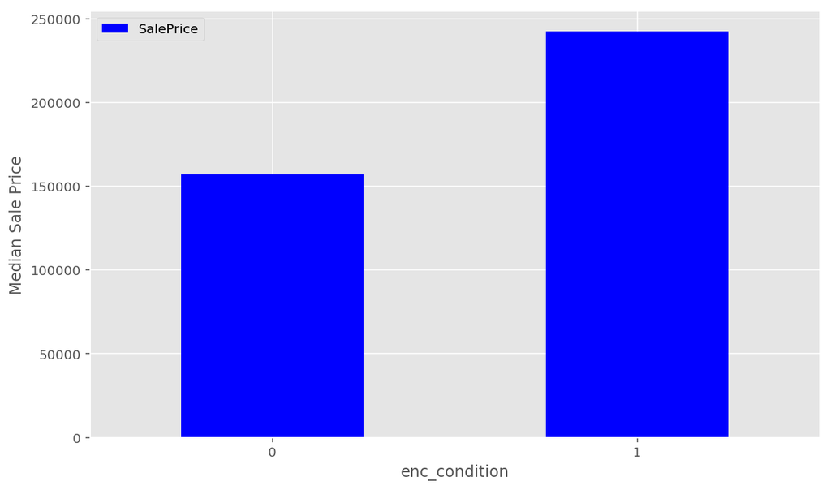

```python
def encode(x):return 1 if x=='Partial' else 0
train['enc_condition'] = train.SaleCondition.apply(encode)
test['enc_condition'] = test.SaleCondition.apply(encode)

condition_pivot = train.pivot_table(index='enc_condition', values='SalePrice', aggfunc=np.median)
condition_pivot.plot(kind='bar',color='blue')
plt.xlabel('enc_condition')
plt.ylabel('Median Sale Price')
plt.xticks(rotation=0)
plt.show()
```

你可以继续对更多的特征进行处理，来改善你建立的模型。

```python
data = train.select_dtypes(include=[np.number]).interpolate().dropna()
```

```python
sum(data.isnull().sum() !=0 )
```

```
0
```

# 建立线性模型

让我们来完成建模前数据准备的最后步骤：分离建模的特征变量和目标变量。将特征变量分配给x，将目标变量分配给y，如上所述，使用np.log()来改变模型的y变量。

使用 data.drop([features], axis=1这个语句来告诉pandas想要排除的列。很明显SalePrice不会包含在变量内，同样id只是SalePrice并没有关联关系的一个索引。

```python
y = np.log(train.SalePrice)
x = data.drop(['SalePrice','Id'], axis=1)
```

```python
from sklearn.model_selection import train_test_split
X_train, X_test, y_train, y_test = train_test_split(x, y ,random_state=42, test_size=.33)

print len(X_train)
```

```
974
```

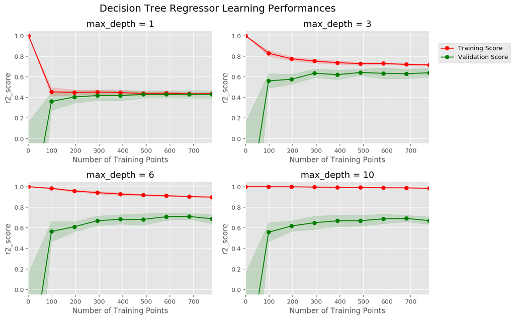

```python
import visuals as vs # Supplementary code
vs.ModelLearning(X_train, y_train)
```

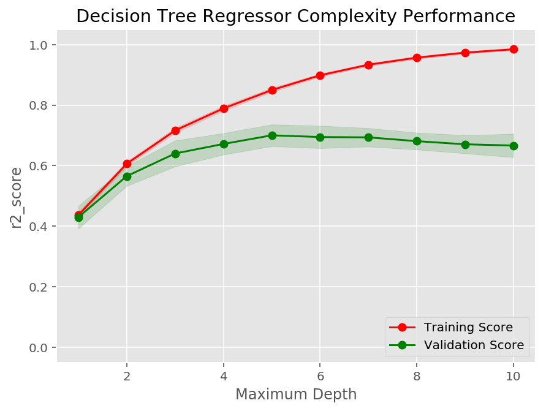

```python
vs.ModelComplexity(X_train, y_train)
```

```python
from sklearn import linear_model
lr = linear_model.LinearRegression()
model = lr.fit(X_train, y_train)
```

```python
print "R^2 is:", model.score(X_test, y_test)
```

```
R^2 is: 0.888247770926
```

```python
predictions = model.predict(X_test)
```

```python
from sklearn.metrics import mean_squared_error
print "RMSE is", mean_squared_error(y_test, predictions)
```

```
RMSE is 0.0178417945196
```

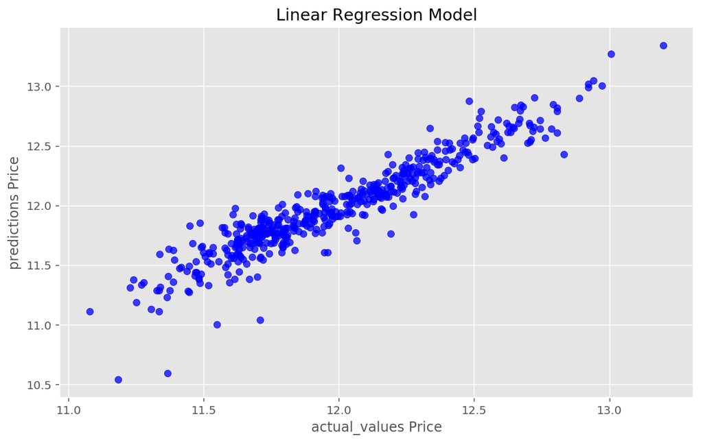

```python
actual_values = y_test
plt.scatter(predictions, actual_values, alpha=.75, color='b')
plt.ylabel("predictions Price")
plt.xlabel("actual_values Price")
plt.title('Linear Regression Model')
plt.show()
```

```python
#提示: 导入 'KFold' 'DecisionTreeRegressor' 'make_scorer' 'GridSearchCV'
from sklearn.model_selection import KFold
from sklearn.tree import DecisionTreeRegressor
from sklearn.metrics import make_scorer
from sklearn.model_selection import GridSearchCV


def fit_model(X, y):
    """ 基于输入数据 [X,y]，利于网格搜索找到最优的决策树模型"""
    cross_validator = KFold(n_splits=10)
    #cross_validator.get_n_splits(X)


    regressor  = DecisionTreeRegressor(random_state=0)


    params = {"max_depth":range(1,11)}
    #print params

    scoring_fnc = make_scorer(performance_metric)

    grid = GridSearchCV(regressor, params, scoring_fnc, cv=cross_validator)
    grid = grid.fit(X, y)
    # 返回网格搜索后的最优模型
    #print pd.DataFrame(grid.cv_results_)
    return grid.best_estimator_
```

```python
def performance_metric(y_true, y_predict):
    """计算并返回预测值相比于预测值的分数"""
    from sklearn.metrics import r2_score
    score = r2_score(y_true, y_predict)

    return score

# 基于训练数据，获得最优模型
optimal_reg = fit_model(X_train, y_train)

# 输出最优模型的 'max_depth' 参数
print "Parameter 'max_depth' is {} for the optimal model.".format(optimal_reg.get_params()['max_depth'])
```

```
Parameter 'max_depth' is 5 for the optimal model.
```

```python
r2 = performance_metric(y_test, optimal_reg.predict(X_test))

print "Optimal model has R^2 score {:,.2f} on test data".format(r2)
```

```
Optimal model has R^2 score 0.74 on test data
```

如果预测值与实际值相同，则该图将为直线y = x，因为每个预测值x将等于每个实际值y。

尝试改进模型

接下来我们尝试使用岭正则化(Ridge Regularization)来减少非关键特征变量的影响， 岭正则化(Ridge Regularization)是收缩非关键特征的回归系数的过程。

现在再次实例化模型，岭正则化(Ridge Regularization)模型使用一个参数α，用来控制正则化的强度。

我们将通过循环赋于几个不同的 α值来进行实验，并观察它们如何改变我们的结果。

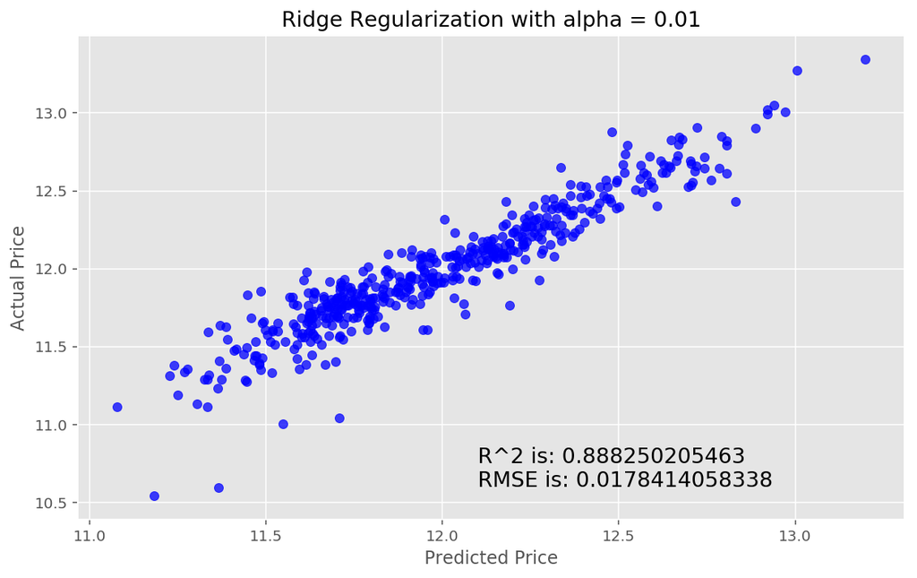

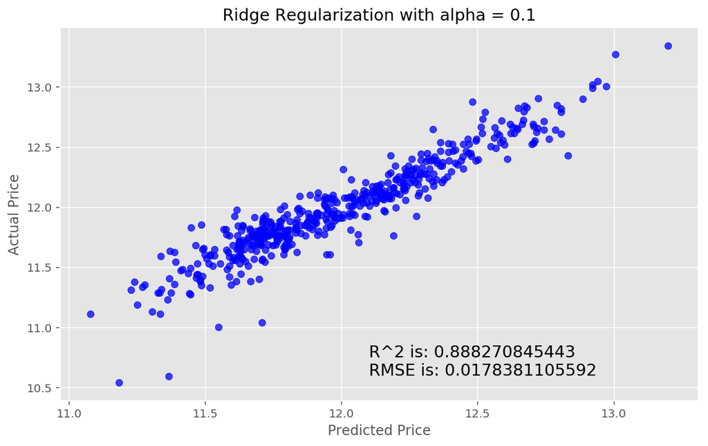

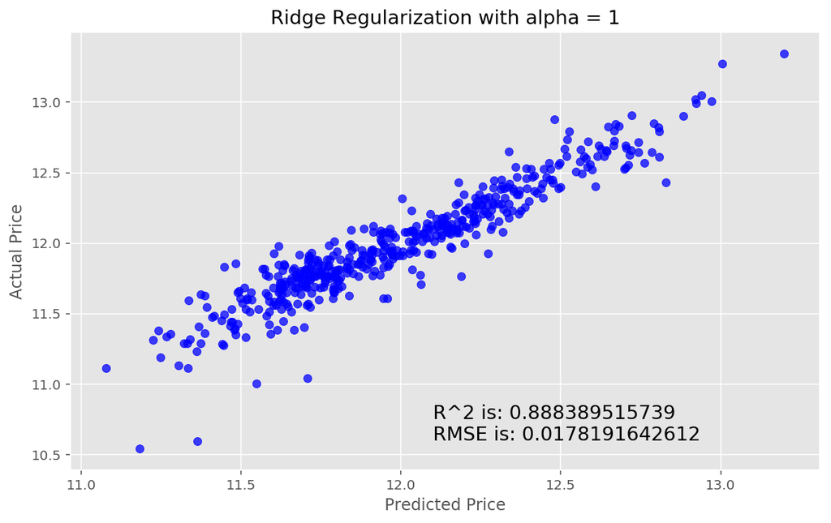

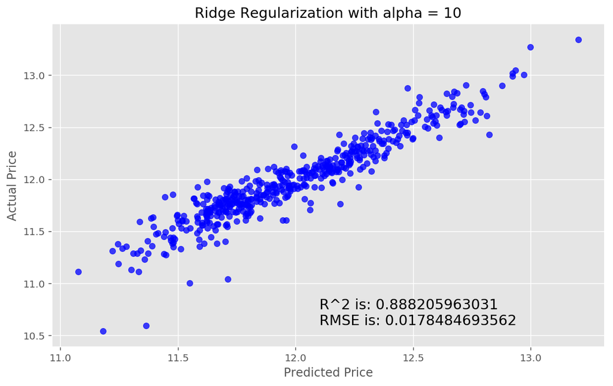

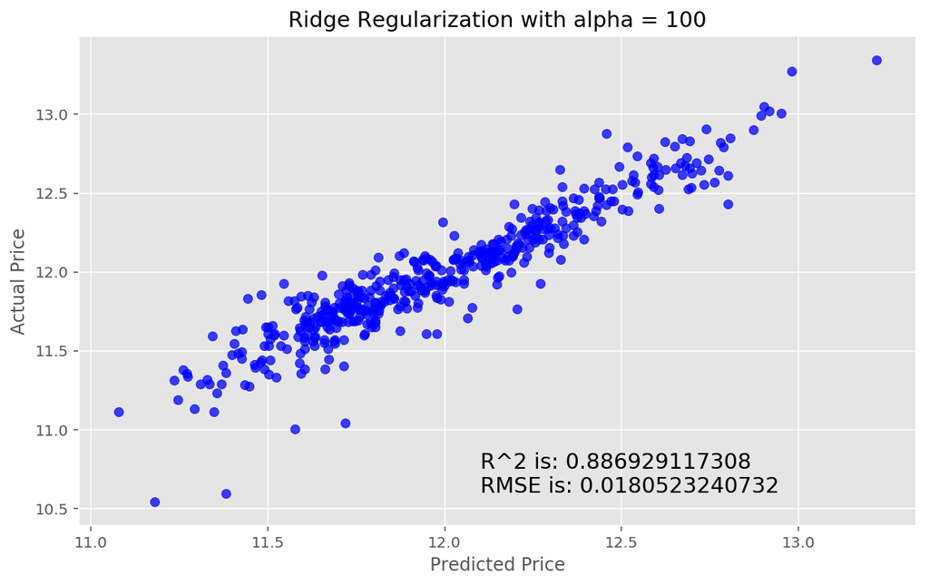

```python
for i in range (-2, 3):
    alpha = 10**i
    rm = linear_model.Ridge(alpha=alpha)
    ridge_model = rm.fit(X_train, y_train)
    preds_ridge = ridge_model.predict(X_test)

    plt.scatter(preds_ridge, actual_values, alpha=.75, color='b')
    plt.xlabel('Predicted Price')
    plt.ylabel('Actual Price')
    plt.title('Ridge Regularization with alpha = {}'.format(alpha))
    overlay = 'R^2 is: {}\nRMSE is: {}'.format(
                    ridge_model.score(X_test, y_test),
                    mean_squared_error(y_test, preds_ridge))
    plt.annotate(s=overlay,xy=(12.1,10.6),size='x-large')
    plt.show()
```

# 步骤四：提交

```python
submission = pd.DataFrame()
submission['Id'] = test.Id
```

```python
feats = test.select_dtypes(include=[np.number]).drop(['Id'], axis=1).interpolate()
predictions = model.predict(feats)
final_predictions = np.exp(predictions)
print ("Original predictions are: \n", predictions[:5], "\n")
print ("Final predictions are: \n", final_predictions[:5])
```

```
('Original predictions are: \n', array([ 11.76725362,  11.71929504,  12.07656074,  12.20632678,  12.11217655]), '\n')
('Final predictions are: \n', array([ 128959.49172585,  122920.74024358,  175704.82598102,
        200050.83263755,  182075.46986405]))
```

```python
submission['SalePrice'] = final_predictions
submission.head()
```

|  | Id | SalePrice |
| --- | --- | --- |
| 0 | 1461 | 128959.491726 |
| 1 | 1462 | 122920.740244 |
| 2 | 1463 | 175704.825981 |
| 3 | 1464 | 200050.832638 |
| 4 | 1465 | 182075.469864 |

```python
submission.to_csv('submission1.csv', index=False)
```